# Homework1

Simay Gökalp

18 Nisan 2021

# Part A

### Exchange Rates

The data group that I will examine is exchange rates I will examine both dolar and euro starting from 2010 to 2021 on the daily basis. I will also check the two rates correlation and plot them on a scatter plot to see their relation.

Calling the required libraries:

```r
library(readxl)
library(readr)
library(ggplot2)
library(data.table)
library(zoo)
```

#### Dollar

Reading and regulating the format of the dollar data and controlling the data types:

```r
dolar <- read_excel("dolar.xlsx")
names(dolar) = c("date", "dolar_value")
dolar <- as.data.table(dolar[2:2945,1:2])
dolar$date <- format(as.Date(dolar$date, format = "%d/%m/%Y"), "%Y-%m-%d")
dolar$date <- as.Date(dolar$date)
str(dolar)
```

```
## Classes 'data.table' and 'data.frame':   2944 obs. of  2 variables:
##  $ date       : Date, format: "2010-01-04" "2010-01-05" ...
##  $ dolar_value: num  1.49 1.48 1.47 1.47 1.47 ...
##  - attr(*, ".internal.selfref")=<externalptr>
```

The data types are correct. Plotting dollar rates and the fitting line:

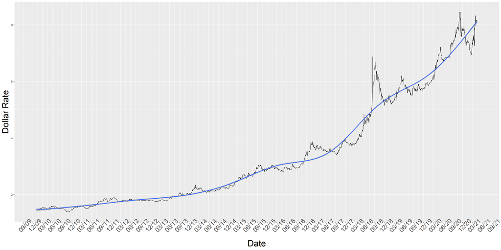

```r
ggplot(dolar, aes(x=date, y=dolar_value)) +
  geom_line() +
  xlab("") + scale_x_date(date_breaks = "3 month", date_labels = "%m/%y") + stat_smooth() +
  theme(axis.text.x = element_text(size = 18)) +  theme(axis.text.x = element_text(angle = 45)) +
    xlab("Date") + ylab("Dollar Rate") + theme(axis.title.x = element_text(size = 25)) + theme(axis.title.y=element_text(size = 25))
```

We can examine the dollar data:

Overall we can see an increasing trend in dollar rates and the increase is sharpening in the last two years as we can see from the fitting line.

There is no observable monthly or quarterly effect as dollar exchange rates does not depend on season or the month but depends on the economic decisions and policies on both side government. However, we observe a trend on the extreme points of the graph.

The first abnormality on 09.18 which is the date when the president of TCMB is changed suddenly and it creates an insecure enviroment for Turkish currency. Another abnormability is again happening when the president of TCMB is changed. We can drive the conclusion that unexpected changes in the president of TCMB cause dramatic rises in dollar rates.

#### Euro

```r
euro <- read_excel("euro.xlsx")
names(euro) = c("date", "euro_value")
euro <- as.data.table(euro[2:2945,])
euro$date <- format(as.Date(euro$date, format = "%d/%m/%Y"), "%Y-%m-%d")
euro$date <- as.Date(euro$date)
str(euro$date)
```

```
##  Date[1:2944], format: "2010-01-04" "2010-01-05" "2010-01-06" "2010-01-07" "2010-01-08" ...
```

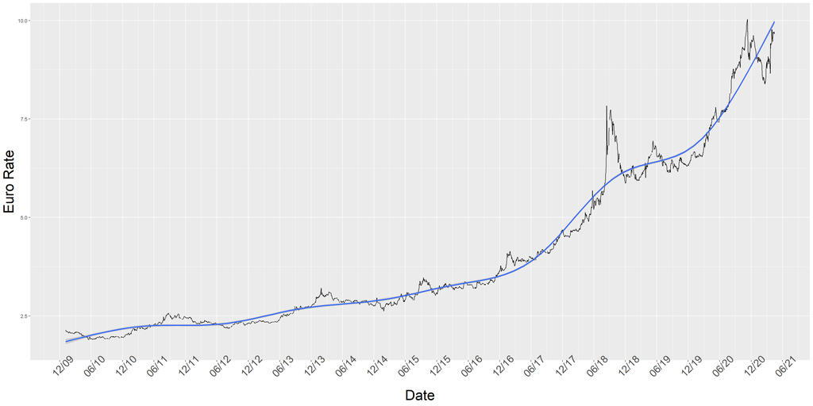

```r
ggplot(euro, aes(x=date, y=euro_value)) +
  geom_line() +
  xlab("") + scale_x_date(date_breaks = "6 month", date_labels = "%m/%y") + stat_smooth() +
  theme(axis.text.x = element_text(size = 18)) +  theme(axis.text.x = element_text(angle = 45)) +
    xlab("Date") + ylab("Euro Rate") + theme(axis.title.x = element_text(size = 25)) + theme(axis.title.y=element_text(size = 25))
```

The data is following a very similar pattern in comparison to Euro because they both depends on Turkey’s economic environment. We can observe the the overall increasing trend and sudden changes resulting from the change of the TCMB’s president. Montly or quarterly trend cannot be seen.

#### The Correlation between Euro and Dollar

```r
euro_dolar <- dolar[,Euro:=euro$euro_value]
cor(euro_dolar$Euro , euro_dolar$dolar_value,  method = "pearson", use = "complete.obs")
```

```
## [1] 0.9937468
```

The correllation is positive and it is extremely high as we expected. Plotting to understand the relationship better:

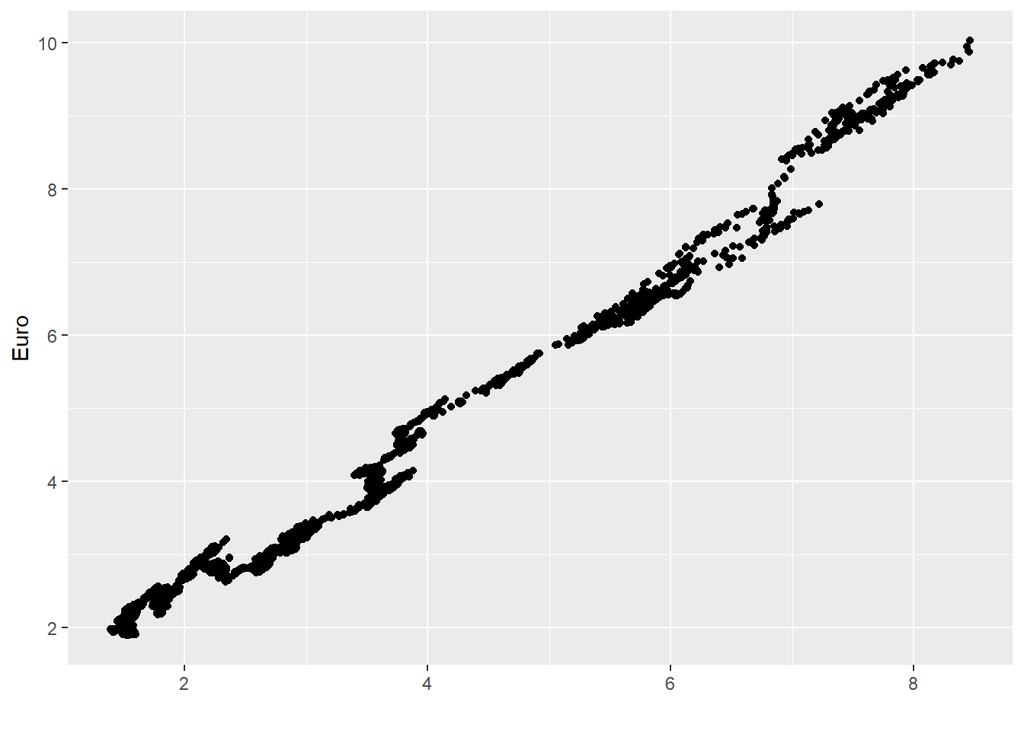

```r
par(mar = c(4, 4, .1, .1))
ggplot(euro_dolar, aes(x=dolar_value, y=Euro)) +
  geom_point() +
  xlab("")

ggplot(euro_dolar, aes(x=date)) +
  geom_line(aes(y = Euro), color = "red") +
  geom_line(aes(y = dolar_value), color="blue")
```

[output not shown]

### Interest Rates

The second data group that I will examine is the interest rates I will examine both consumer loans and mortgage loans starting from 2010 to 2021 on the weekly basis. I will also check the two rates correlation. Generally TCMB changes the interest rates according to the dollar rates. To catch this trend I will examine them on the same plot.

#### Consumer Loans Interest

Reading the consumer loan interest data.

```r
ihtiyac <- read_excel("ihtiyac.xlsx")
names(ihtiyac) = c("date", "ihtiyac_index")
ihtiyac <- as.data.table(ihtiyac)
ihtiyac$date <- format(as.Date(ihtiyac$date, format = "%d/%m/%Y"), "%Y-%m-%d")
ihtiyac$date <- as.Date(ihtiyac$date)
```

Plotting the graph:

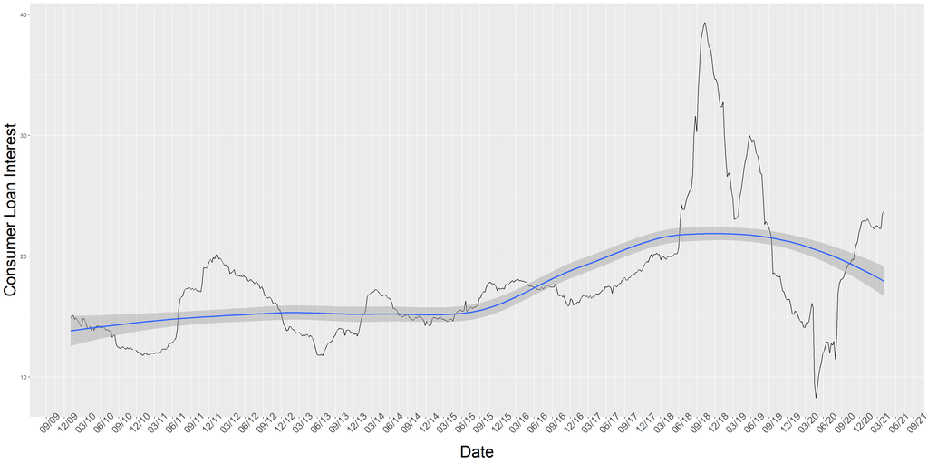

```r
ggplot(ihtiyac, aes(x=date, y=ihtiyac_index)) +
  geom_line() +
  xlab("") + scale_x_date(date_breaks = "3 month", date_labels = "%m/%y") + stat_smooth() +
    theme(axis.text.x = element_text(size = 15)) +  theme(axis.text.x = element_text(angle = 45)) +
    xlab("Date") + ylab("Consumer Loan Interest") + theme(axis.title.x = element_text(size = 25)) + theme(axis.title.y=element_text(size = 25))
```

On this data we observe fluctuations. On 04.2020 we can see the sharp decrease due to the Covid support. On 10.18 after the currency rates are very high, TCMB increased the interest rates. Then it is gradually decreasing until Covid it reaches it is minimum level and then it starts to increase. Again the trend does not depend on month or quarter but the events.

Reading the mortgage interest data.

```r
konut <- read_excel("konut.xlsx")
names(konut) = c("date", "konut")
konut <- as.data.table(konut)
konut$date <- format(as.Date(konut$date, format = "%d/%m/%Y"), "%Y-%m-%d")
konut$date <- as.Date(konut$date)
```

Plotting the graph:

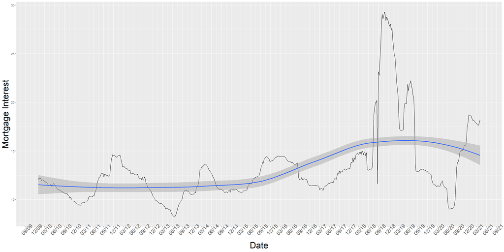

```r
ggplot(konut, aes(x=date, y=konut)) +
  geom_line() +
  xlab("") + scale_x_date(date_breaks = "3 month", date_labels = "%m/%y") + stat_smooth() +
    theme(axis.text.x = element_text(size = 15)) +  theme(axis.text.x = element_text(angle = 45)) +
    xlab("Date") + ylab("Mortgage Interest") + theme(axis.title.x = element_text(size = 25)) + theme(axis.title.y=element_text(size = 25))
```

The trends are very similar to consumer loan interest. The explanations above can be given also for that graph.

#### Correlation and Impact Analysis

As we can see from the graph, we expect high correlation between two data.

```r
konut_ihtiyac <- konut[,ihtiyac:=ihtiyac$ihtiyac_index]
cor(konut_ihtiyac$konut, konut_ihtiyac$ihtiyac, method = "pearson", use = "complete.obs")
```

```
## [1] 0.9432285
```

As expected the correlation is positive and exteremly high.

Next, we will try to answer the question whether we can explain interest rates and currency rates by comparing their time series. First we need to scale the dollar rates and add a secondary axis to make a meaningful interpretation.

Regulation the data and plotting:

```r
dolar_haftalik <- read_excel("dolar_haftalik.xlsx")
```

```
## * `` -> ...3
```

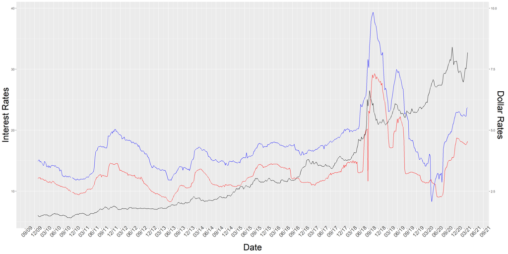

```r
dolar_haftalik <- dolar_haftalik[1:588,1:2]
konut_ihtiyac <- konut[,dolar:=dolar_haftalik[,2]]
konut_ihtiyac$dolar <- as.numeric(konut_ihtiyac$dolar)*4

ggplot(konut_ihtiyac, aes(x=date)) +
  geom_line(aes(y = konut), color = "red") +
  geom_line(aes(y = ihtiyac), color="blue") + geom_line(aes(y = dolar), color = "black")+
  scale_y_continuous(
    name = "Interest Rates",
    sec.axis = sec_axis( trans=~.*0.25, name="Dollar Rates")
  ) + scale_x_date(date_breaks = "3 month", date_labels = "%m/%y") +
    theme(axis.text.x = element_text(size = 15)) +  theme(axis.text.x = element_text(angle = 45)) +
    xlab("Date") + ylab("Consumer Loan") + theme(axis.title.x = element_text(size = 25)) + theme(axis.title.y=element_text(size = 25))
```

On this graph we can see that right after the rise in 2018, interest rates are increased. This justifies our theory. Also, we can say that wen the interest rates are lowered dollar rates kept increasing. For example in 09/16 we can see after the loan interest lowered dollar rates increased.

## Price Index

The third data group that I will examine is the price index. I will examine general price index and education price index starting from 2004 to 2021 on the monthly basis.

Reading the data:

```r
egitim_endex <- read_excel("egitim_endex.xlsx")
```

```
## * `` -> ...3
```

```r
fiyatendex <- read_excel("fiyatendex.xlsx")
egitim_endex<-egitim_endex[1:207,1:2]
egitim_endex<- as.data.table(egitim_endex)
egitim_fiyat <- egitim_endex[,fiyatendex:=fiyatendex[,2]]
names(egitim_fiyat) <- c("date","egitimendex","fiyatendex")
egitim_fiyat$egitimendex <- as.numeric(egitim_fiyat$egitimendex)

egitim_fiyat$date <- as.Date(as.yearmon(egitim_fiyat$date))
str(egitim_fiyat)
```

```
## Classes 'data.table' and 'data.frame':   207 obs. of  3 variables:
##  $ date       : Date, format: "2004-01-01" "2004-02-01" ...
##  $ egitimendex: num  112 112 112 112 112 ...
##  $ fiyatendex : num  105 106 108 108 106 ...
##  - attr(*, ".internal.selfref")=<externalptr>
```

Plotting the time series:

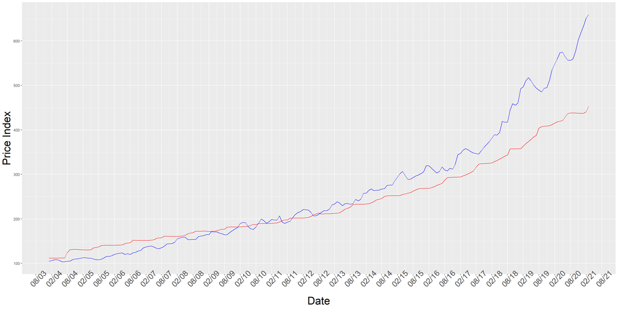

```r
ggplot(egitim_fiyat, aes(x=date)) +
  geom_line(aes(y =egitimendex ), color = "red") +
  geom_line(aes(y = fiyatendex), color="blue")  +
  xlab("") + scale_x_date(date_breaks = "6 month", date_labels = "%m/%y") + scale_x_date(date_breaks = "6 month", date_labels = "%m/%y") +
  theme(axis.text.x = element_text(size = 18)) +  theme(axis.text.x = element_text(angle = 45)) +
    xlab("Date") + ylab("Price Index") + theme(axis.title.x = element_text(size = 25)) + theme(axis.title.y=element_text(size = 25)) + theme(legend.position="right")
```

The red line is education index and the blue is the general price index. Until 2011, education price index was higher than the general but then general price index has surpassed it. Although education is getting more expensive each day, general prices are worst than this.

We can see that both price indeces have an increasing trend. The living in Turkey is getting more expensive almost every day. There is no seasionality data. And the trends seems to be almost exponential.

# Part B

In this part I will examine Google trends data and try to observe the similarity between my economic data and google trends to see whether really the interest of the people in Turkey is on the data.

### Exchange Rates

For exchange rates we have observed that the abnormal activities happened when the president of TCMB is changed. To test my hypothesis I first obtained the data for “merkez bankası”.

Reading and plotting the data:

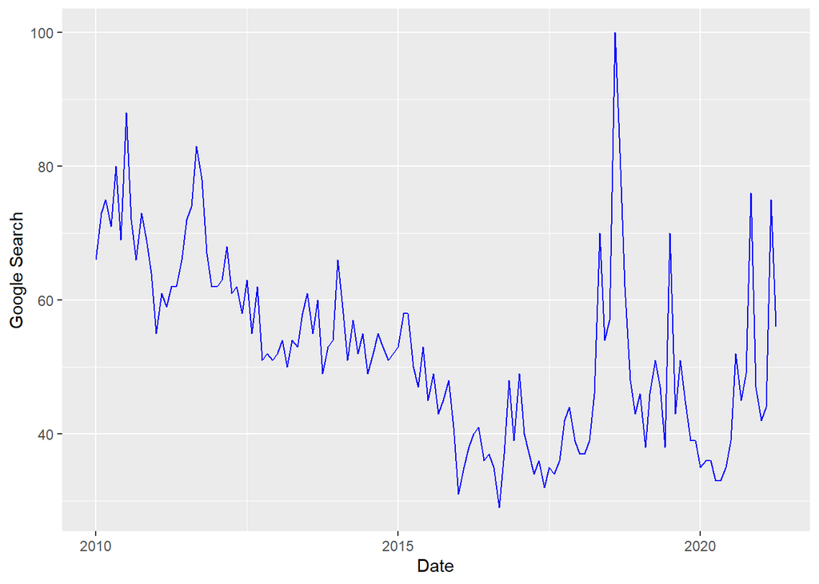

```r
par(mar = c(4, 4, .1, .1))

google_merkez <- read_csv("google_merkez.csv",
                          col_types = cols(Month = col_date(format = "%Y-%m")))
names(google_merkez) <- c("Month","merkez")
ggplot(google_merkez, aes(x=Month)) +
  geom_line(aes(y = merkez), color = "blue") + xlab("Date")+ ylab("Google Search")

ggplot(euro_dolar, aes(x=date)) +
  geom_line(aes(y = Euro), color = "red") +
  geom_line(aes(y = dolar_value), color="blue")
```

[output not shown]

The results are not surprising we can see the peak point of the google trend data, on 09.2018 “merkez bankası” searches has reached its maximum value. Again we can see in the near time TCMB has searches a lot and again euro and dolar rates are high.

Next, for exchange rates we will examine euro and dollar search. Our hypothesis is the strong movements may cause people to search more on the online.

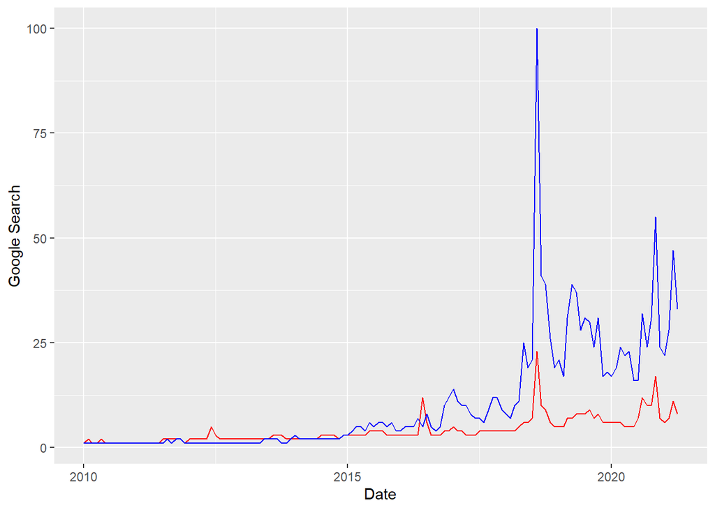

```r
google_dolar_euro <- read_csv("google_dolar_euro.csv",
                              col_types = cols(Month = col_date(format = "%Y-%m")))

ggplot(google_dolar_euro, aes(x=Month)) +
  geom_line(aes(y = euro), color = "red") +
  geom_line(aes(y = dolar), color="blue") + xlab("Date") + ylab("Google Search")

ggplot(euro_dolar, aes(x=date)) +
  geom_line(aes(y = Euro), color = "red") +
  geom_line(aes(y = dolar_value), color="blue")
```

[output not shown]

As we can see from graph, dollar is more popular than euro. And our hytpothesis again correct. The high jumps in the currency rates attacts people attention and cause them to make google searches.

### Interest Rates

For the interest rates we will examine “faiz” and “kredi”. Our hypothesis is people will search when the the interest rates are low they are tend to search for to apply a loan.

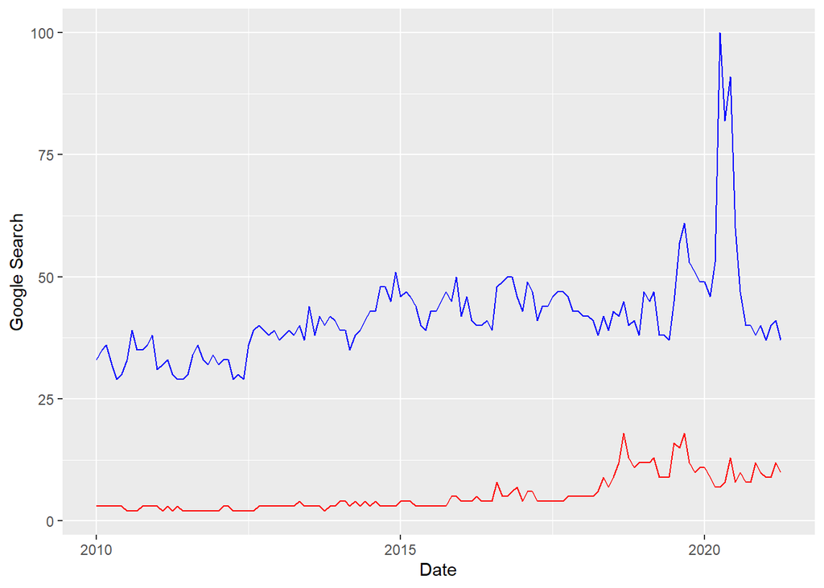

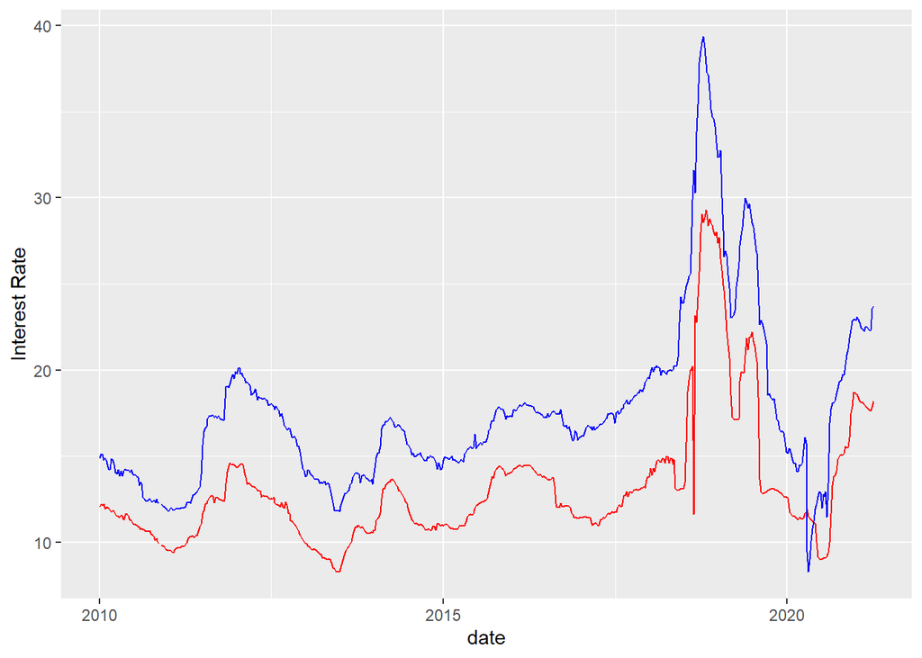

```r
google_faiz_kredi <- read_csv("google_faiz_kredi.csv",
                              col_types = cols(Month = col_date(format = "%Y-%m")))

ggplot(google_faiz_kredi, aes(x=Month)) +
  geom_line(aes(y = faiz), color = "red") +
  geom_line(aes(y = kredi), color="blue")+ xlab("Date") + ylab("Google Search")

ggplot(konut_ihtiyac, aes(x=date)) +
  geom_line(aes(y = konut), color = "red") +
  geom_line(aes(y = ihtiyac), color="blue") + ylab("Interest Rate")
```

The data shows people need loans most during the covid times. When the loans were lowered there are lots of people who applied to get a loan as we can see from the data. The peak points has a reverse relationship.

### Price Index

For the price index data, “pahalı” is the key word. I believe as the prices increases people tend to complain more about them and search expensive in google.

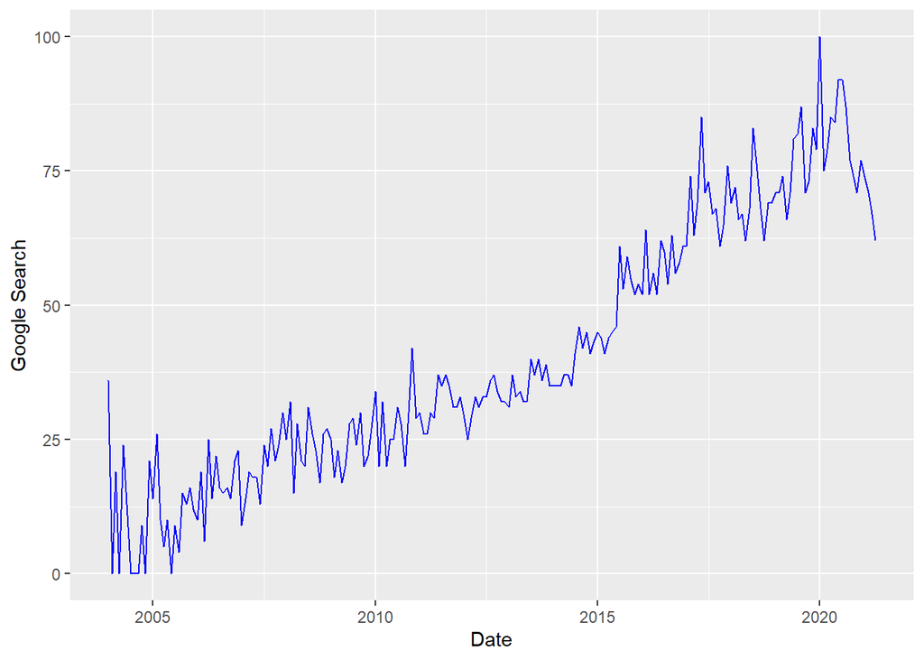

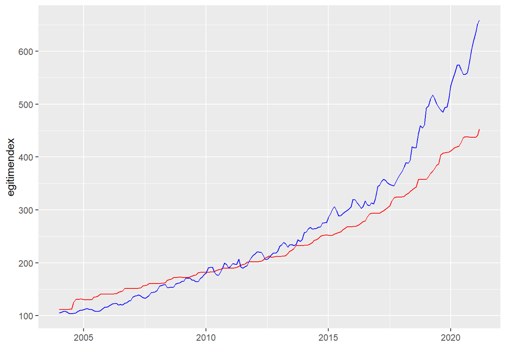

```r
google_pahali <- read_csv("google_pahali.csv",
                          col_types = cols(Month = col_date(format = "%Y-%m")))
ggplot(google_pahali, aes(x=Month)) +
  geom_line(aes(y = pahali), color="blue")+ xlab("Date")+ ylab("Google Search")

ggplot(egitim_fiyat, aes(x=date)) +
  geom_line(aes(y =egitimendex ), color = "red") +
  geom_line(aes(y = fiyatendex), color="blue")  +
  xlab("")
```

In both graphs we can see the increasing trend. As life getting expensive in Turkey people search more about the expensiveness of the life. We have obtained a similar pattern and let’s examine this relationship also on a scatter plot.

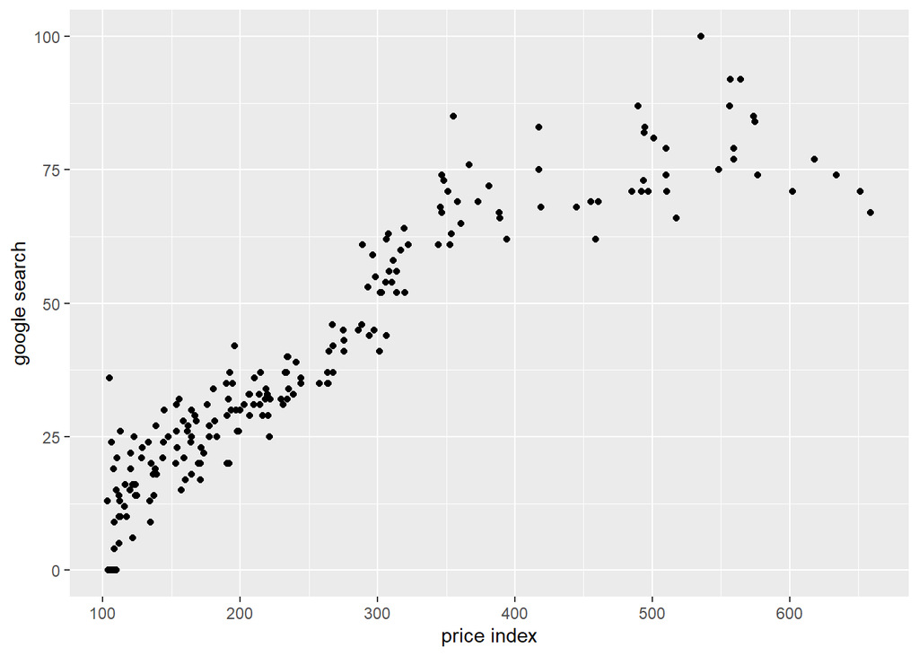

```r
a <- google_pahali[1:207,]
egitim_fiyat <- egitim_fiyat[,google:=a$pahali]

ggplot(egitim_fiyat, aes(x=fiyatendex)) +
  geom_point(aes(y = google)) + ylab("google search") + xlab("price index")
```

The scatter plot shows that as price index increases first the google searh increases. But then the google search cannot catch up with the velocity in the increase of the prices.